# Assignment1

Ritesh Sengar

2023-10-18

## Understanding the Source of data and other data characteristics:

Source : http://data.un.org/Data.aspx?d=IFS&f=SeriesCode%3ac2 International Financial Statistics (IFS) is a standard source of international statistics on all aspects of international and domestic finance. It reports, for most countries of the world, current data needed in the analysis of problems of international payments and of inflation and deflation, i.e., data on exchange rates, international liquidity, international banking, money and banking, interest rates, prices, production, international transactions, government accounts, and national accounts. The data contains total of 8669 records and contains the columns OID, Country or Area, Year, Description, Magnitude and Value.

```r
library(tidyverse)
```

```r
library(dplyr)
library(ggplot2)
library(knitr)
library(kableExtra)
# Load the data from the CSV file
data <- read.csv("Assignment1-Ritesh.csv", header = TRUE)
# Display the first 10 rows of the DataFrame
first_10_rows <- head(data, n = 10)

kable(first_10_rows, "html") %>%
  kable_styling("striped")
```

| OID | Country.or.Area | Year | Description | Magnitude | Value |
| --- | --- | --- | --- | --- | --- |
| 512c2M..BA… | AFGHANISTAN, I.R. OF | 2009 | TOTAL CASH EXPENDITURE [2+31] | AFGHANIS | 1.12473e+11 |
| 512c25..BA… | AFGHANISTAN, I.R. OF | 2009 | SUBSIDIES | AFGHANIS | 2.97863e+05 |
| 512c27..BA… | AFGHANISTAN, I.R. OF | 2009 | SOCIAL BENEFITS | AFGHANIS | 5.57188e+09 |
| 512c22..BA… | AFGHANISTAN, I.R. OF | 2009 | PURCHASES OF GOODS & SERVICES | AFGHANIS | 2.52297e+10 |
| 512c28..BA… | AFGHANISTAN, I.R. OF | 2009 | OTHER PAYMENTS | AFGHANIS | 3.15370e+08 |
| 512c24..BA… | AFGHANISTAN, I.R. OF | 2009 | INTEREST | AFGHANIS | 1.03937e+08 |
| 512c26..BA… | AFGHANISTAN, I.R. OF | 2009 | GRANTS | AFGHANIS | 7.77660e+07 |
| 512c21..BA… | AFGHANISTAN, I.R. OF | 2009 | COMPENSATION OF EMPLOYEES | AFGHANIS | 5.44711e+10 |
| 512c2…BA… | AFGHANISTAN, I.R. OF | 2009 | CASH PAYMENTS FOR OPERATING ACTIVITI | AFGHANIS | 8.57700e+10 |
| 512c2M..BA… | AFGHANISTAN, I.R. OF | 2008 | TOTAL CASH EXPENDITURE [2+31] | AFGHANIS | 1.09768e+11 |

```r
# Describe the summary of data
summary(data)
```

```
##      OID            Country.or.Area         Year      Description
##  Length:8669        Length:8669        Min.   :1948   Length:8669
##  Class :character   Class :character   1st Qu.:1991   Class :character
##  Mode  :character   Mode  :character   Median :1998   Mode  :character
##                                        Mean   :1995
##                                        3rd Qu.:2004
##                                        Max.   :2009
##   Magnitude             Value
##  Length:8669        Min.   :-3.182e+07
##  Class :character   1st Qu.: 5.665e+08
##  Mode  :character   Median : 9.025e+09
##                     Mean   : 9.937e+12
##                     3rd Qu.: 1.389e+11
##                     Max.   : 8.987e+15
```

Dataframe is tidy because all columns are variables and no values are present as column names. Each observation is seperate observation and is present in its individual row. Each values has its own cell and no-combination of different values is seen here.

## Making it Untidy by applying pivot_wider

```r
#Pivot Wider to make it untidy
data <- data |> pivot_wider(names_from=Year,values_from = Value)
kable(head(data), "html") %>%
  kable_styling("striped")
```

| OID | Country.or.Area | Description | Magnitude | 2009 | 2008 | 2007 | 2006 | 2005 | 2004 | 2003 | 2002 | 2001 | 2000 | 1999 | 1998 | 1997 | 1996 | 1995 | 1994 | 1993 | 1992 | 1991 | 1990 | 1989 | 1988 | 1987 | 1986 | 1985 | 1984 | … |
| --- | --- | --- | --- | --- | --- | --- | --- | --- | --- | --- | --- | --- | --- | --- | --- | --- | --- | --- | --- | --- | --- | --- | --- | --- | --- | --- | --- | --- | --- | --- |
| 512c2M..BA… | AFGHANISTAN, I.R. OF | TOTAL CASH EXPENDITURE [2+31] | AFGHANIS | 1.12473e+11 | 1.09768e+11 | 98588400000 | 77888700000 | 52001700000 | 45236900000 | 30547600000 | NA | NA | NA | NA | NA | NA | NA | NA | NA | NA | NA | NA | NA | NA | NA | NA | NA | NA | NA | … |
| 512c25..BA… | AFGHANISTAN, I.R. OF | SUBSIDIES | AFGHANIS | 2.97863e+05 | 4.45000e+06 | 700000 | 8000000 | 8640000 | 47687300 | 181122000 | NA | NA | NA | NA | NA | NA | NA | NA | NA | NA | NA | NA | NA | NA | NA | NA | NA | NA | NA | … |
| 512c27..BA… | AFGHANISTAN, I.R. OF | SOCIAL BENEFITS | AFGHANIS | 5.57188e+09 | 3.81231e+09 | 3243770000 | 2676980000 | 1935230000 | 1365650000 | 686496000 | NA | NA | NA | NA | NA | NA | NA | NA | NA | NA | NA | NA | NA | NA | NA | NA | NA | NA | NA | … |
| 512c22..BA… | AFGHANISTAN, I.R. OF | PURCHASES OF GOODS & SERVICES | AFGHANIS | 2.52297e+10 | 3.02987e+10 | 28379400000 | 24779500000 | 19707500000 | 22221900000 | 10921700000 | NA | NA | NA | NA | NA | NA | NA | NA | NA | NA | NA | NA | NA | NA | NA | NA | NA | NA | NA | … |
| 512c28..BA… | AFGHANISTAN, I.R. OF | OTHER PAYMENTS | AFGHANIS | 3.15370e+08 | 6.73574e+08 | 18920000 | 61894000 | 982963000 | 573900000 | 38654900 | NA | NA | NA | NA | NA | NA | NA | NA | NA | NA | NA | NA | NA | NA | NA | NA | NA | NA | NA | … |
| 512c24..BA… | AFGHANISTAN, I.R. OF | INTEREST | AFGHANIS | 1.03937e+08 | 1.03089e+08 | 106723000 | 169353000 | 149941000 | 97925700 | 42105600 | NA | NA | NA | NA | NA | NA | NA | NA | NA | NA | NA | NA | NA | NA | NA | NA | NA | NA | NA | … |

The data is now untidy because the values are spread across multiple columns, one column for each category type. This makes it difficult to perform calculations on the data, and to consider it as tidy data all the values need to be combined in a single column

## Making it tidy again

Dataframe is tidy because all columns are variables and no values are present as column names. Each observation is seperate observation and is present in its individual row. Each values has its own cell and no-combination of different values is seen here.

```r
selected_columns <- data[, 5:ncol(data)]
col_names <- colnames(selected_columns)
data <- data |> pivot_longer(all_of(col_names), names_to = "Year",values_to = "Value")

kable(head(data), "html") %>%
  kable_styling("striped")
```

| OID | Country.or.Area | Description | Magnitude | Year | Value |
| --- | --- | --- | --- | --- | --- |
| 512c2M..BA… | AFGHANISTAN, I.R. OF | TOTAL CASH EXPENDITURE [2+31] | AFGHANIS | 2009 | 1.12473e+11 |
| 512c2M..BA… | AFGHANISTAN, I.R. OF | TOTAL CASH EXPENDITURE [2+31] | AFGHANIS | 2008 | 1.09768e+11 |
| 512c2M..BA… | AFGHANISTAN, I.R. OF | TOTAL CASH EXPENDITURE [2+31] | AFGHANIS | 2007 | 9.85884e+10 |
| 512c2M..BA… | AFGHANISTAN, I.R. OF | TOTAL CASH EXPENDITURE [2+31] | AFGHANIS | 2006 | 7.78887e+10 |
| 512c2M..BA… | AFGHANISTAN, I.R. OF | TOTAL CASH EXPENDITURE [2+31] | AFGHANIS | 2005 | 5.20017e+10 |
| 512c2M..BA… | AFGHANISTAN, I.R. OF | TOTAL CASH EXPENDITURE [2+31] | AFGHANIS | 2004 | 4.52369e+10 |

## Cash Payment in Algeria after year 2000

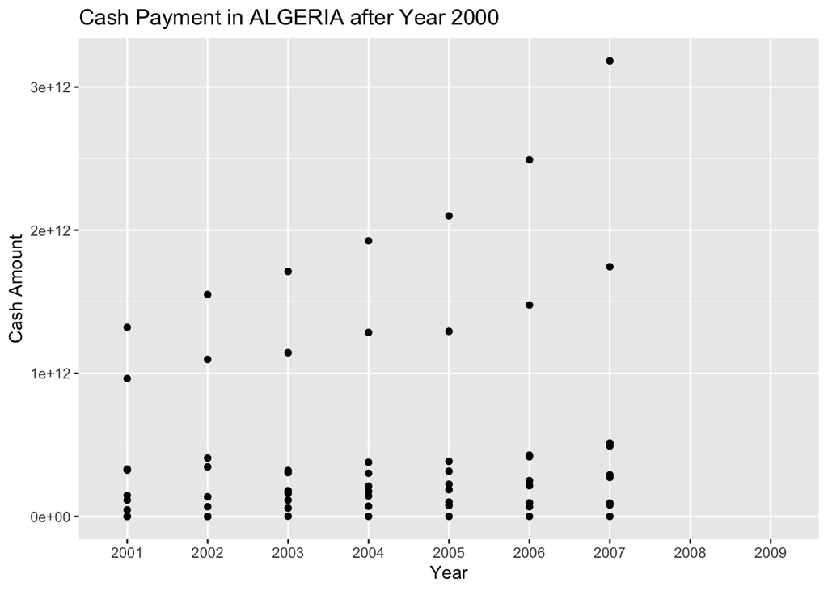

```r
df <- data[data$Country.or.Area == 'ALGERIA' & data$Year > 2000, ]
ggplot(df, aes(x = Year, y = Value)) +
  geom_point() +
  labs(title = "Cash Payment in ALGERIA after Year 2000",
       x = "Year",
       y = "Cash Amount")
```

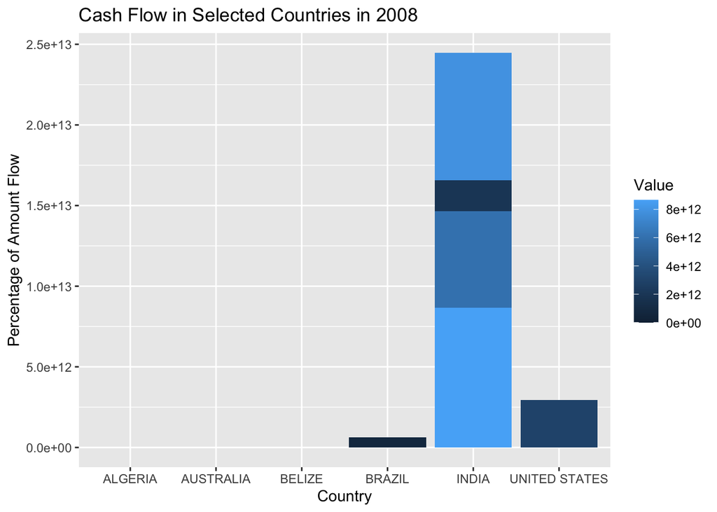

```r
# List of countries you want to filter
selected_countries <- c('INDIA', 'UNITED STATES', 'ALGERIA', 'AUSTRALIA', 'BELIZE', 'BRAZIL')

# Filter the dataframe for the year 2008
df_2008 <- data[data$Year == 2008,]

# Filter the dataframe for the selected countries
df_2008 <- subset(df_2008, Country.or.Area %in% selected_countries)

# Create a bar plot for the selected countries in 2008
ggplot(df_2008, aes(x=df_2008$Country.or.Area, y=Value,fill= Value)) +
  geom_bar(stat = "identity") +
  labs(title = "Cash Flow in Selected Countries in 2008",
       x = "Country",
       y = "Percentage of Amount Flow")
```

As per the bar chart it is indicated that in 2008 India is the leading country in terms of cash payments followed by United States and Brazil